# 数据可视化

人民大学-钟保罗-2019101155

2019-11-10

# 一、数据可视化

## 1 柱状图、饼图、点图、风玫瑰图

绘制柱状图、饼图、点图、风玫瑰图，并将这几张图放在一个图形界面中显示；

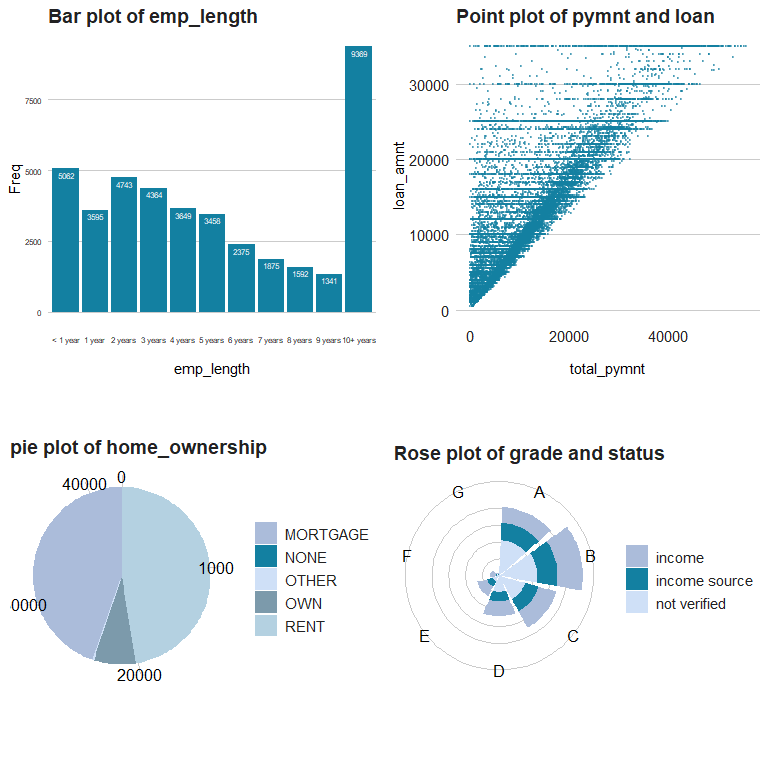

## 2 直方图

某一个连续型变量的分布直方图，并加入拟合分布线，直方图的组距和组数根据直方图经验公式设定（不要使用默认的），并且每个柱子里面填上相应的组的频数，整个图片加一个黑色的外框，并且图的底色为白色，柱子为红色，在密度最高的部分加上文字标注“此处密度最大”。

本次选择funded_amnt变量来画分布直方图。

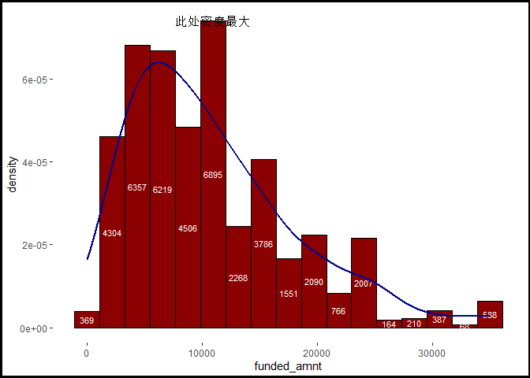

## 3 二维密度图

某两个连续型变量的密度图和分箱化的密度图

本次选择installment和total_rec_prncp两个连续型变量，grade作为类别型变量进行分箱。

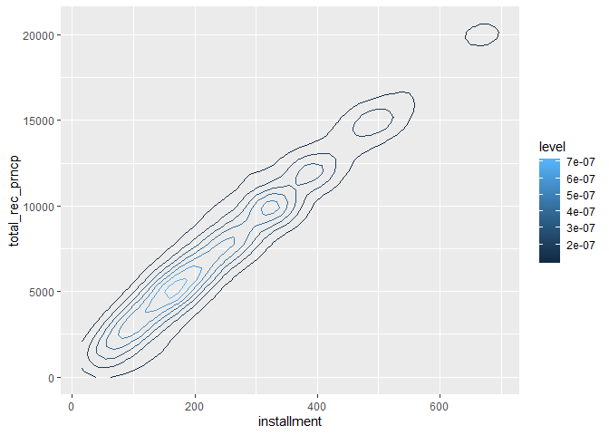

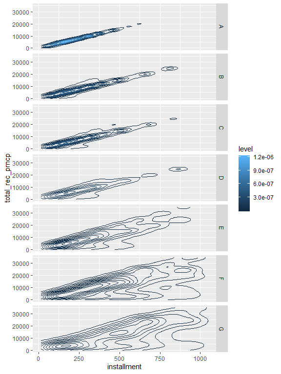

## 4 聚类热图

挑选多个连续型变量，进行聚类，并且绘制相应的热图，并进行美化（可以不用全部样本

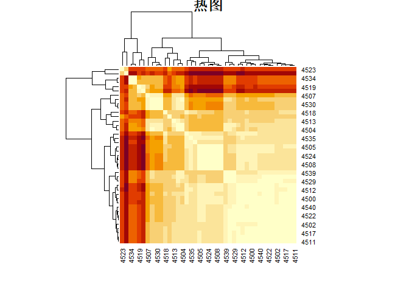

# 二、地图

# 附录：R代码

```r
library(ggplot2)
library(bbplot)
library(grid)
mytheme1 = bbc_style()+theme(axis.title = element_text(size = 11),axis.text = element_text(size = 11),
                             plot.title = element_text(size = 14),plot.subtitle = element_text(size = 12))
mytheme2 = bbc_style()+theme(axis.title = element_blank(),axis.text = element_blank(),
                             legend.position = "right",legend.text = element_text(size = 11),
                             plot.title = element_text(size = 14),plot.subtitle = element_text(size = 12))
vp = function(x, y) {
  viewport(layout.pos.row = x, layout.pos.col = y)
}
data = read.csv("D:\\大数据相关\\2019大数据统计基础期末考试\\LoanStats3a.csv")
blue = '#1380A1'

# 绘制柱状图、饼图、点图、风玫瑰图，并将这几张图放在一个图形界面中显示
# 工作时间柱形图
data_plot = na.omit(data$emp_length)
data_plot = factor(data$emp_length,levels = c(levels(data_plot)[1:3],levels(data_plot)[5:12],levels(data_plot)[4],"n/a"))
data_plot1 = data.frame(table(data_plot))[2:12,]
p1 = ggplot(data_plot1,aes(x = data_plot,y=Freq))+geom_bar(stat = "identity",fill = blue)+mytheme1+
  labs(title = 'Bar plot of emp_length',x = 'emp_length')+
  geom_label(aes(x = data_plot, y = Freq, label = round(Freq, 0)),hjust = 0.5, vjust = 1,
             colour = "white", fill = NA, label.size = NA, family="Helvetica", size = 2)+theme(axis.text = element_text(size = 6))

# home_ownership饼图
data_plot = na.omit(data$home_ownership)
data_plot1 = data.frame(table(data_plot)[2:6])
label_value = paste('(', round(data_plot1$Freq/sum(data_plot1$Freq) * 100, 1), '%)', sep = '')
label = paste(data_plot1$data_plot, label_value, sep = '')
p2 = ggplot(data_plot1,aes(x ='Content',y=Freq,fill=data_plot))+geom_bar(stat = "identity",position = 'stack')+
   labs(x = '', y = '', title = 'pie plot of home_ownership')  +coord_polar(theta = 'y')+mytheme2+
   scale_fill_manual(values =c('#ABBCDA','#1380A1','#CFE0F7','#7C9AAB','#B4D1E1') )
#点图
data_plot = data[,c('total_pymnt','loan_amnt')]
p3 = ggplot(data_plot,aes(x= total_pymnt,y=loan_amnt))+geom_point(color = blue,size = 0.5,alpha =0.5)+
  mytheme1+labs(title = 'Point plot of pymnt and loan')
#风玫瑰图 grade 为分类变量,loan_status/verification_status作为堆叠变量
data_plot = data[,c('loan_status','verification_status','grade')]
data_plot = na.omit(data_plot)
data_plot = data_plot[data_plot$verification_status!='',]
data_plot$verification_status = gsub(pattern = "VERIFIED - ", replacement = "", x = data_plot$verification_status)
p4 = ggplot(data_plot,aes(x=grade,y=..count..,fill=verification_status))+
  geom_bar()+ coord_polar()+mytheme2+labs(title = 'Rose plot of grade and status')+
  theme(legend.position = "right",legend.text = element_text(size = 11))+
  scale_fill_manual(values =c('#ABBCDA','#1380A1','#CFE0F7','#7C9AAB','#B4D1E1') )

grid.newpage()
pushViewport(viewport(layout = grid.layout(2, 2)))
print(p1,vp = vp(1,1));print(p3,vp = vp(1,2))
print(p2,vp = vp(2,1));print(p4,vp = vp(2,2))

## 直方图
funded_amnt = na.omit(data$funded_amnt)
k = round(1+log(length(funded_amnt))/log(2))
width_k = max(funded_amnt)/k
breaks=seq(-width_k/2, max(funded_amnt)+width_k/2, by=width_k)
amnt = cut(funded_amnt,breaks)
data_plot = data.frame(table(amnt))
data_plot$breaks = breaks[-length(breaks)]+width_k/2
data_plot$density = data_plot$Freq/sum(data_plot$Freq)/width_k
mydata = data.frame(funded_amnt)
ggplot(mydata,aes(x = funded_amnt))+
  geom_histogram(aes(y = ..density..),binwidth = width_k,color = 'black',fill = 'darkred')+
  geom_text(aes(x = breaks,y = density/2,label = Freq),color = 'white',data = data_plot,size = 3)+
  geom_line(stat="density", adjust=3, col="darkblue",size=1)+
  theme(plot.background=element_rect(fill="white",colour="black ",size=2),panel.background=element_rect(fill=NA))+
  annotate(geom="text",x=data_plot$breaks[which.max(data_plot$density)],y=max(data_plot$density),label="此处密度最大")

## 密度图
plot_data = data[,c('installment',"total_rec_prncp",'grade')]
plot_data$grade = as.character(plot_data$grade)
plot_data = plot_data[plot_data$grade !='',]
ggplot(plot_data, aes(installment, total_rec_prncp))+stat_density2d(aes(color = ..level..))

ggplot(plot_data, aes(installment, total_rec_prncp))+stat_density2d(aes(color = ..level..))+
  facet_grid(grade ~ .)


## 聚类热图
data_new = data[c(4500:4540),c('loan_amnt','out_prncp',
                               'total_pymnt','total_rec_prncp',
                               'total_rec_int')]
data_new = na.omit(data_new)
data_new = scale(data_new)
distance = as.matrix(dist(data_new,method= 'euclidean'))
heatmap(distance,symm=TRUE,main = '热图')

Data=read.csv("D:\\大数据相关\\2019大数据统计基础期末考试\\province.csv",header=TRUE,stringsAsFactors=FALSE)[-c(2,1),]

library(REmap)
options(remap.ak="bMUmEwmBAPC1sGABp8Snzo67eRnci7t1")
data=Data[,c(1,3)]
province2 = Data[,c(1,3)]

prov=mapNames("china")  #获取中国省份名称
prov_geo=get_geo_position(prov)  #获取中国省份经纬度数据
province2$指标 = gsub(' ','',province2$指标)
colnames(province2) = c('city','value')
province3=merge(x = province2, y = prov_geo, by = "city", all.x = TRUE)
province3=province3[,c('lon','lat','value')]
a=remapH(province3,maptype = 'china',
       blurSize = 40,minAlpha =10,opacity = 1,color='red',
       title = '各省份GDP热力图')

remap.init()

knitrREmap(a, local = F, height = '500px')

data2<-Data[,c(1,2)]#选择年末人口数为变量
data2[,2] = as.numeric(data2[,2])
data2[,1] = gsub(' ','',data2[,1])
a = remapC(data2,maptype="china",title="各省年末人口地图")#绘制地图
remap.init()

knitrREmap(a, local = F, height = '500px')
```